# final_project_ahmad_tokey

# Relationship between accessibility and sociodemographic characteristics

First, we are interested in knowing which areas have higher accessibility and which areas have lower accessibility. Also we want to know the difference between this relationships for safe (passed) and unsafe (failed) food outlets. Thirdly, the accessibility varies with travel time. Previously we used 15 minutes travel time. So, we are interested to know how the relationship changes with different accessibility measured by different distance.

So, we arranged a sensitivity analysis. First, we will calculate the accessibility scores for passed groceries with 9 different travel time threshold (from 10 min to 50 min, with 5 min interval). Second, we will model the access scores with the sociodemographic variables and store the coefficients in a data frame. This whole process is completed with a for loop. Lastly, we will process the dataframe in a way to use it later for the comparative analysis with failed groceries. To keep the extent of analysis limited, we will not analyze the bakeries here.

(Since the for loops take huge amount of time, we will show the codes for only two travel time in a loop. The main report contains complete analytical output.)

### model coefficient for passed groceries

```r
library(stats)
library(data.table)
ct_var <- ct_C %>% subset(select=c(med_incomeE,insur_percE, unempl_rateE,hh18_percE,hh65_percE,GEOID))
OD_filt <- filter(OD, Facility.Type=="Grocery Store", Results=="Pass")
time <- c(10,15)#,20,25,30,35,40,45,50)

for(i in 1:length(time)){
  #calculating accessibility
  supply_ratio <- OD_filt  %>%  #spatial join facility with zip areas by GEOID and then taking sum
    st_drop_geometry(OD_filt) %>%
    filter(Total_TravelTime<time[i]) %>%
    group_by(Inspection.ID) %>%
    filter(!is.na(tot_popE))%>%
    summarise(sumpop=sum(tot_popE))%>%
    mutate(ratio = 1/sumpop)

  demand = merge(x=OD_filt, y=supply_ratio, by="Inspection.ID", all.x=TRUE)
  demand2 <- demand %>%
    #st_drop_geometry(demand) %>%
    filter(Total_TravelTime<time[i]) %>%
    group_by(GEOID)  %>%
    summarise(access=1000*sum(ratio)) %>%
    st_drop_geometry()
  ct_var <- ct_var %>%
    left_join(demand2, by = "GEOID")
  #modeling access score
  model <- lm(access~ med_incomeE+insur_percE+ unempl_rateE+hh18_percE+hh65_percE, data=ct_var)
  ct_var <- ct_var %>% subset(select=-c(access)) # get ready for another loop

  coeffx <- model$coefficients %>% as.data.frame() # get the coefficients

  colnames(coeffx) <- paste0("time",time[i])
  # populate the data frame
  if(i==1){coeff = coeffx } else{
    coeff=cbind(coeffx,coeff)}
}

# storing coefficient for future use

groc_var <- data.frame(var=c("Intercept", "med_incomeE","insur_percE", "unempl_rateE","hh18_percE","hh65_percE"))

coeff_p <- cbind(groc_var,coeff)
coeff_longP <- melt(coeff_p, id.vars=c("var"), value.names=c("coefficient")) %>% mutate(model="grocery pass")
head(coeff_longP)
```

```
##            var variable         value        model
## 1    Intercept   time15  5.410615e-02 grocery pass
## 2  med_incomeE   time15  6.822102e-08 grocery pass
## 3  insur_percE   time15  1.859278e-04 grocery pass
## 4 unempl_rateE   time15  5.261734e-05 grocery pass
## 5   hh18_percE   time15 -1.897304e-04 grocery pass
## 6   hh65_percE   time15 -7.410500e-04 grocery pass
```

### model coefficient for failed groceries

```r
ct_var <- ct_C %>% subset(select=c(med_incomeE,insur_percE, unempl_rateE,hh18_percE,hh65_percE,GEOID))
OD_filt <- filter(OD, Facility.Type=="Grocery Store", Results=="Fail")
time <- c(10,15)#,20,25,30,35,40,45,50)

for(i in 1:length(time)){
  supply_ratio <- OD_filt  %>%  #spatial join facility with zip areas by GEOID and then taking sum
    st_drop_geometry(OD_filt) %>%
    filter(Total_TravelTime<time[i]) %>%
    group_by(Inspection.ID) %>%
    filter(!is.na(tot_popE))%>%
    summarise(sumpop=sum(tot_popE))%>%
    mutate(ratio = 1/sumpop)

  demand = merge(x=OD_filt, y=supply_ratio, by="Inspection.ID", all.x=TRUE)
  demand2 <- demand %>%
    #st_drop_geometry(demand) %>%
    filter(Total_TravelTime<time[i]) %>%
    group_by(GEOID)  %>%
    summarise(access=1000*sum(ratio)) %>%
    st_drop_geometry()
  ct_var <- ct_var %>%
    left_join(demand2, by = "GEOID")

  model <- lm(access~ med_incomeE+insur_percE+ unempl_rateE+hh18_percE+hh65_percE, data=ct_var)
  ct_var <- ct_var %>% subset(select=-c(access))

  coeffx <- model$coefficients %>% as.data.frame()

  colnames(coeffx) <- paste0("time",time[i])

  if(i==1){coeff = coeffx } else{
    coeff=cbind(coeffx,coeff)}
}


head(coeff)
```

```
##                     time15        time10
## (Intercept)   9.894185e-02  1.114796e-01
## med_incomeE  -2.959469e-07 -4.596759e-07
## insur_percE   1.836420e-04  1.877801e-05
## unempl_rateE  1.617691e-03  2.333704e-03
## hh18_percE   -3.826715e-04 -2.685086e-04
## hh65_percE   -5.352132e-04 -5.631167e-04
```

```r
groc_var <- data.frame(var=c("Intercept", "med_incomeE","insur_percE", "unempl_rateE","hh18_percE","hh65_percE"))

coeff_f <- cbind(groc_var,coeff)
coeff_longF <- melt(coeff_f, id.vars=c("var"), value.names=c("coefficient")) %>% mutate(model="grocery fail")
head(coeff_longF)
```

```
##            var variable         value        model
## 1    Intercept   time15  9.894185e-02 grocery fail
## 2  med_incomeE   time15 -2.959469e-07 grocery fail
## 3  insur_percE   time15  1.836420e-04 grocery fail
## 4 unempl_rateE   time15  1.617691e-03 grocery fail
## 5   hh18_percE   time15 -3.826715e-04 grocery fail
## 6   hh65_percE   time15 -5.352132e-04 grocery fail
```

### visualizing the comparison

Now that both the coefficients are ready, we will bind them and show in a ggplot.

```r
coeff_long <- rbind(coeff_longP,coeff_longF) # binding

head(coeff_long)
```

```
##            var variable         value        model
## 1    Intercept   time15  5.410615e-02 grocery pass
## 2  med_incomeE   time15  6.822102e-08 grocery pass
## 3  insur_percE   time15  1.859278e-04 grocery pass
## 4 unempl_rateE   time15  5.261734e-05 grocery pass
## 5   hh18_percE   time15 -1.897304e-04 grocery pass
## 6   hh65_percE   time15 -7.410500e-04 grocery pass
```

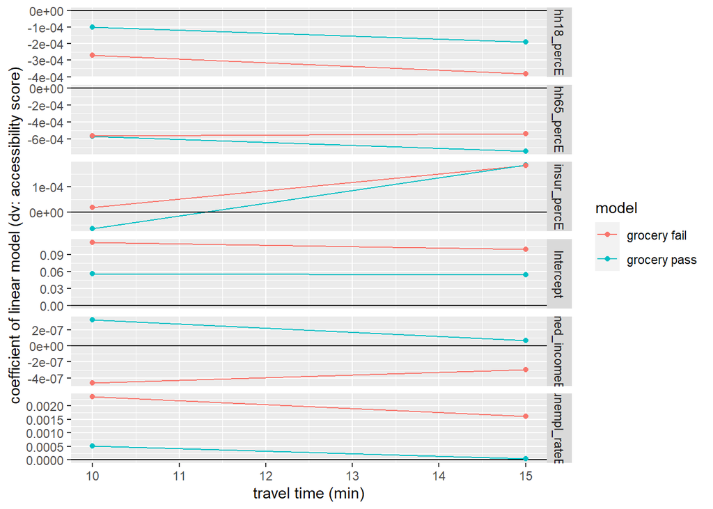

```r
coeff_long$time <- gsub("[a-zA-Z ]", "", coeff_long$variable) %>% as.numeric() # changing times into numeric for better plotting
coeff_long <- coeff_long %>% subset(select=-c(variable))


coeff_plot <- coeff_long %>%
  ggplot() +
  aes(x = time, y = value, color = model) +
  geom_line(aes(group = model)) +
  facet_grid(var ~ ., scales = "free") +
  geom_hline(yintercept = 0, show.legend = T) +
  geom_point() + xlab("travel time (min)") + ylab("coefficient of linear model (dv: accessibility score)")

coeff_plot
```

```r
ggsave(coeff_plot, filename = "coeff_plot.jpeg", path="C:/study/1_OSU/fall 22/lab2/final project", dpi=300, width = 7, height = 8,units = "in")
```

## Evaluating equity

Now since we have calculated the accessibility scores for both passed and failed facilities, we need to compare how every census tract is experiencing the accessibility. This is important to evaluate equity. For this analysis, we will not consider the conditionally passed facilities and focus on only passed and failed food outlets.

### scatter plot of accessibility to safe and unsafe groceries and bakeries

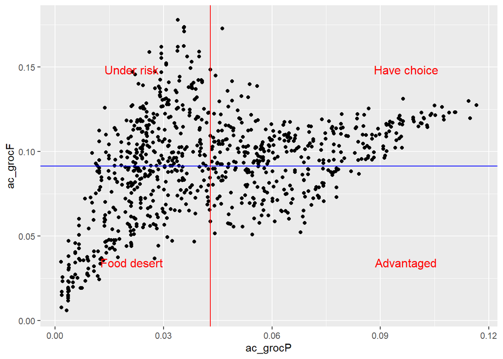

```r
# delineating the regions
library(grid)
grob <- grobTree(textGrob("Advantaged", x=0.8,  y=0.2,gp=gpar(col="red")),
                 textGrob("Have choice", x=0.8,  y=0.8,gp=gpar(col="red")),
                 textGrob("Food desert", x=0.2,  y=0.2,gp=gpar(col="red")),
                 textGrob("Under risk", x=0.2,  y=0.8,gp=gpar(col="red")))

# plotting the scatters
gro_sp <- ggplot(ct_C, aes(x=ac_grocP, y=ac_grocF)) +  geom_point() +
  geom_vline(xintercept = mean(ct_C$ac_grocP,na.rm=TRUE),color="red") + geom_hline(yintercept = mean(ct_C$ac_grocF,na.rm=TRUE),color="blue") + annotation_custom(grob)

gro_sp
```

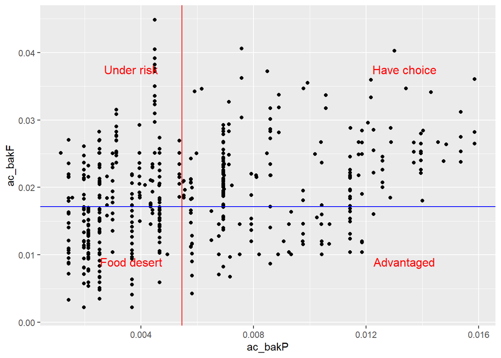

```r
bak_sp <- ggplot(ct_C, aes(x=ac_bakP, y=ac_bakF)) +  geom_point()  +
  geom_vline(xintercept = mean(ct_C$ac_bakP,na.rm=TRUE),color="red") + geom_hline(yintercept = mean(ct_C$ac_bakF,na.rm=TRUE),color="blue") + annotation_custom(grob)
bak_sp
```

```r
#ggsave(gro_sp, filename = "gro_sp.jpeg", path="C:/study/1_OSU/fall 22/lab2/final project", dpi=300, width = 8, height = 5,units = "in")
```

### Categorizing the tracts into equity regions

According to the regions showed above, we will divide the tracts into four categories.

```r
# setting up the cutoff values
gpa <- mean(ct_C$ac_grocP, na.rm=T)
gfa <- mean(ct_C$ac_grocF, na.rm=T)
bpa <- mean(ct_C$ac_bakP, na.rm=T)
bfa <- mean(ct_C$ac_bakF, na.rm=T)

# defining the regions
ct_C <- ct_C %>% mutate(G_class=case_when(ac_grocP>=gpa & ac_grocF>=gfa~"have choice",
                                  ac_grocP<gpa & ac_grocF>gfa~"under risk",
                                  ac_grocP<gpa & ac_grocF<gfa~"food desert",
                                  ac_grocP>gpa & ac_grocF<gfa~"advantaged")) %>%
  mutate(B_class=case_when(ac_bakP>bpa & ac_bakF>bfa~"have choice",
                                  ac_bakP<bpa & ac_bakF>bfa~"under risk",
                                  ac_bakP<bpa & ac_bakF<bfa~"food desert",
                                  ac_bakP>bpa & ac_bakF<bfa~"advantaged"))
# get the frequency
table(ct_C$G_class)
```

```
##
##  advantaged food desert have choice  under risk
##         122         254         252         233
```

```r
table(ct_C$B_class)
```

```
##
##  advantaged food desert have choice  under risk
##         101         302         216         165
```

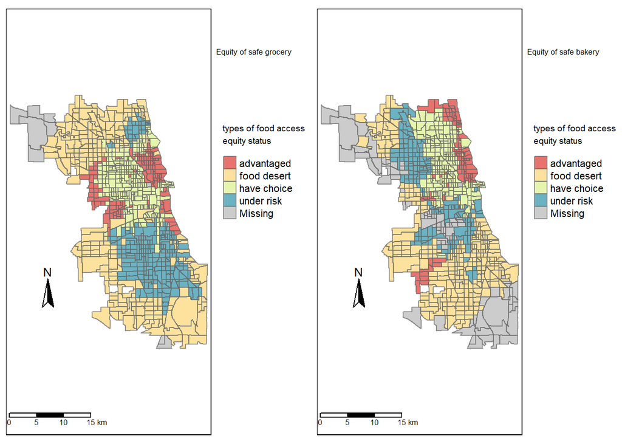

```r
#plotting
equity_gro <- tm_shape(ct_C) + tm_polygons(col="G_class", alpha=0.8, style = "cat",palette = "Spectral",
              border.alpha=0.7, title = "types of food access \nequity status") + tm_borders("gold", lty = "dashed") +
  tm_scale_bar(width = 0.32, position = c(0,.01)) +
  tm_compass(size=2,position = c(.1,.3)) +
  tm_layout(frame = T, title = "Equity of safe grocery",
      title.size = 1.5, title.position = c(.05,.9), legend.outside = T, legend.position = c(.1,.5))


equity_bak <- tm_shape(ct_C) + tm_polygons(col="B_class", alpha=0.8, style = "cat",palette = "Spectral",
              border.alpha=0.7, title = "types of food access \nequity status") + tm_borders("gold", lty = "dashed") +
  tm_scale_bar(width = 0.32, position = c(0,.01)) +
  tm_compass(size=2,position = c(.1,.3)) +
  tm_layout(frame = T, title = "Equity of safe bakery",
      title.size = 1.5, title.position = c(.05,.9), legend.outside = T, legend.position = c(.1,.5))


tmap_arrange(equity_gro, equity_bak)
```

# Modeling the regions

```r
library(nnet)

#setting up the reference category

ct_C$G_class <- as.factor(ct_C$G_class) %>% relevel(ct_C$G_class, ref = "advantaged")

table(ct_C$G_class)
```

```
##
##  advantaged food desert have choice  under risk
##         122         254         252         233
```

```r
# creating model for grocery equity category
gro_class <- multinom(G_class ~ med_incomeE+insur_percE+ unempl_rateE+hh18_percE+hh65_percE, data = ct_C)
```

```r
library(sjPlot)


tab_model(gro_class, show.loglik=T, show.se=F, show.ci = T, file = "C:/study/1_OSU/fall 22/lab2/final project/result_gro_class.xls")
```

|  | G_class |  |  |  |
| --- | --- | --- | --- | --- |
| Predictors | Odds Ratios | CI | p | Response |
| (Intercept) | 0.11 | 0.00 – Inf | **<0.001** | food desert |
| med incomeE | 1.00 | 0.00 – Inf | **<0.001** | food desert |
| insur percE | 1.03 | 0.00 – Inf | **<0.001** | food desert |
| unempl rateE | 0.95 | 0.00 – Inf | **<0.001** | food desert |
| hh18 percE | 1.01 | 0.00 – Inf | **0.017** | food desert |
| hh65 percE | 1.06 | 0.00 – Inf | **<0.001** | food desert |
| (Intercept) | 0.65 | 0.00 – Inf | **<0.001** | have choice |
| med incomeE | 1.00 | 0.00 – Inf | **<0.001** | have choice |
| insur percE | 1.05 | 0.00 – Inf | **<0.001** | have choice |
| unempl rateE | 0.99 | 0.00 – Inf | 0.179 | have choice |
| hh18 percE | 0.99 | 0.00 – Inf | **0.011** | have choice |
| hh65 percE | 0.99 | 0.00 – Inf | **0.007** | have choice |
| (Intercept) | 0.82 | 0.00 – Inf | **<0.001** | under risk |
| med incomeE | 1.00 | 0.00 – Inf | **<0.001** | under risk |
| insur percE | 1.02 | 0.00 – Inf | **<0.001** | under risk |
| unempl rateE | 1.07 | 0.00 – Inf | **<0.001** | under risk |
| hh18 percE | 0.98 | 0.00 – Inf | **<0.001** | under risk |
| hh65 percE | 1.03 | 0.00 – Inf | **<0.001** | under risk |
| Observations | 861 |  |  |  |
| R<sup>2</sup> / R<sup>2</sup> adjusted | 0.149 / 0.148 |  |  |  |
| log-Likelihood | -989.258 |  |  |  |

## ploting predicted probability plot for grocery equity

To visualize the relationship with different probabilities beyond model result table, plotting the predicted probabilities is a powerful way. We will plot the predictor variable (e.g., median income) in x axis and probaility of four regions in y axis. This code will do this for groceries.

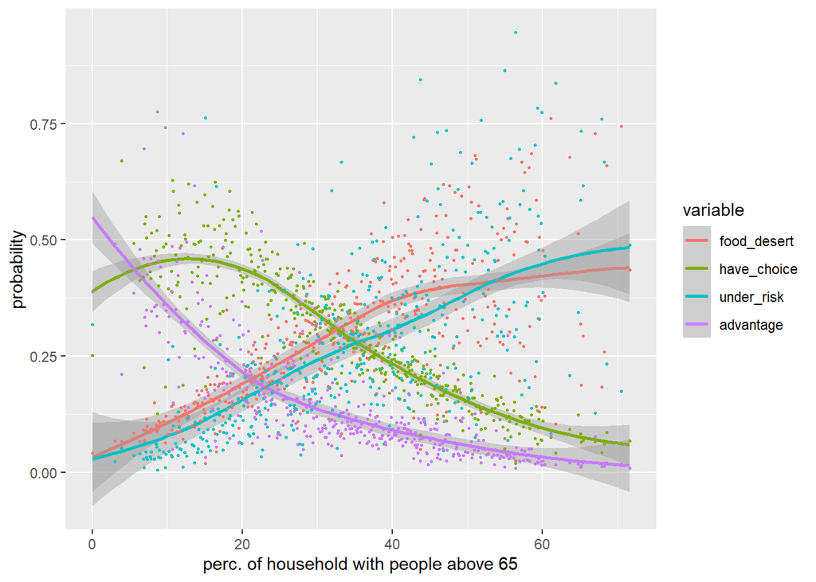

```r
library(data.table)
#predict the outcome
pp.write <- cbind(ct_C, predict(gro_class, newdata = ct_C, type = "probs", se = TRUE)) %>% as.data.table()

# craete dataframe with predicted probability of four categories for predictor variables
for_plot <- pp.write %>%
  group_by(hh65_percE) %>%
  summarise(food_desert=mean(food.desert),have_choice=mean(have.choice),under_risk=mean(under.risk),advantage=mean(advantaged),) %>%
  as.data.table()

# make that in a long formate

for_plot <-  melt(for_plot, id.vars=c("hh65_percE"), value.name = "probability")

for_plot[,1] <- lapply(for_plot[,1], as.numeric)

# plot
p2 <- for_plot %>%
  ggplot() +
  aes(x = hh65_percE, y = probability, color = variable) +
  #geom_line(aes(group = variable)) +
  geom_smooth(method=loess, se=T, fullrange=TRUE) +
  geom_point(size=.5) + xlab("perc. of household with people above 65")

p2
```

```r
#ggsave(p2, filename = "gro_class_a65.jpeg", path="C:/study/1_OSU/fall 22/lab2/final project", dpi=300, width = 8, height = 4,units = "in")
```